# Titanic: Machine Learning from Disaster

Abdaljbbar B. A. Dawod

10th September, 2020

To build a prediction model in **R**, several steps should be performed sequentially. This project is structured in a way that will lead us to extract a prediction model by utilizing the provided datasets for training and testing purposes. Therefore, this project is arranged as:

Reading dataset into R environment

```r
train = read.csv("D:\\Datasets\\Titanic\\train.csv")
```

Show the structure of the loaded dataset

```r
str(train)    #the structure of our data
```

```
## 'data.frame':    891 obs. of  12 variables:
##  $ PassengerId: int  1 2 3 4 5 6 7 8 9 10 ...
##  $ Survived   : int  0 1 1 1 0 0 0 0 1 1 ...
##  $ Pclass     : int  3 1 3 1 3 3 1 3 3 2 ...
##  $ Name       : Factor w/ 891 levels "Abbing, Mr. Anthony",..: 109 191 358 277 16 559 520 629 417 581 ...
##  $ Sex        : Factor w/ 2 levels "female","male": 2 1 1 1 2 2 2 2 1 1 ...
##  $ Age        : num  22 38 26 35 35 NA 54 2 27 14 ...
##  $ SibSp      : int  1 1 0 1 0 0 0 3 0 1 ...
##  $ Parch      : int  0 0 0 0 0 0 0 1 2 0 ...
##  $ Ticket     : Factor w/ 681 levels "110152","110413",..: 524 597 670 50 473 276 86 396 345 133 ...
##  $ Fare       : num  7.25 71.28 7.92 53.1 8.05 ...
##  $ Cabin      : Factor w/ 148 levels "","A10","A14",..: 1 83 1 57 1 1 131 1 1 1 ...
##  $ Embarked   : Factor w/ 4 levels "","C","Q","S": 4 2 4 4 4 3 4 4 4 2 ...
```

# Data transformation.

Changing the Structure of some variables from integer to **factor-type**.

```r
lab = c("No", "Yes")
train$Survived = factor(train$Survived, levels = c(0, 1), labels =lab)
train$Pclass =  as.factor(train$Pclass)
train$Name = as.character(train$Name)
```

Summarizing the loaded dataset.

```r
summary(train)
```

```
##   PassengerId    Survived  Pclass      Name               Sex
##  Min.   :  1.0   No :549   1:216   Length:891         female:314
##  1st Qu.:223.5   Yes:342   2:184   Class :character   male  :577
##  Median :446.0             3:491   Mode  :character
##  Mean   :446.0
##  3rd Qu.:668.5
##  Max.   :891.0
##
##       Age            SibSp           Parch             Ticket
##  Min.   : 0.42   Min.   :0.000   Min.   :0.0000   1601    :  7
##  1st Qu.:20.12   1st Qu.:0.000   1st Qu.:0.0000   347082  :  7
##  Median :28.00   Median :0.000   Median :0.0000   CA. 2343:  7
##  Mean   :29.70   Mean   :0.523   Mean   :0.3816   3101295 :  6
##  3rd Qu.:38.00   3rd Qu.:1.000   3rd Qu.:0.0000   347088  :  6
##  Max.   :80.00   Max.   :8.000   Max.   :6.0000   CA 2144 :  6
##  NA's   :177                                      (Other) :852
##       Fare                Cabin     Embarked
##  Min.   :  0.00              :687    :  2
##  1st Qu.:  7.91   B96 B98    :  4   C:168
##  Median : 14.45   C23 C25 C27:  4   Q: 77
##  Mean   : 32.20   G6         :  4   S:644
##  3rd Qu.: 31.00   C22 C26    :  3
##  Max.   :512.33   D          :  3
##                   (Other)    :186
```

Loading the ggplot package for visualization purposes

```r
library(ggplot2)
```

Plotting the number of survived passengers *Vs* dead passengers

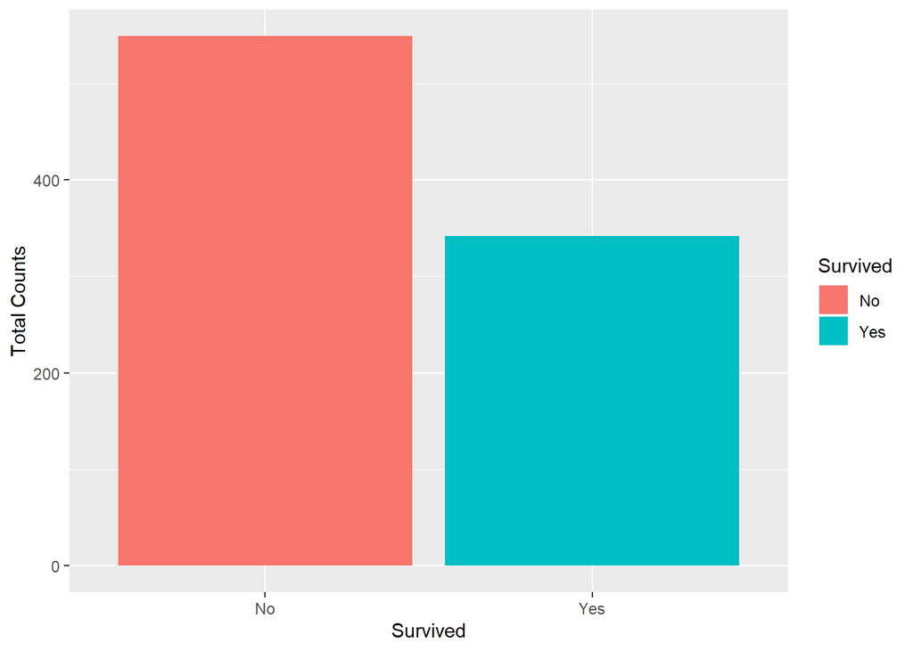

```r
ggplot(data = train, aes(x = Survived, fill = Survived)) + geom_bar() + ylab("Total Counts")
```

Plotting the survival status passengers according to their class

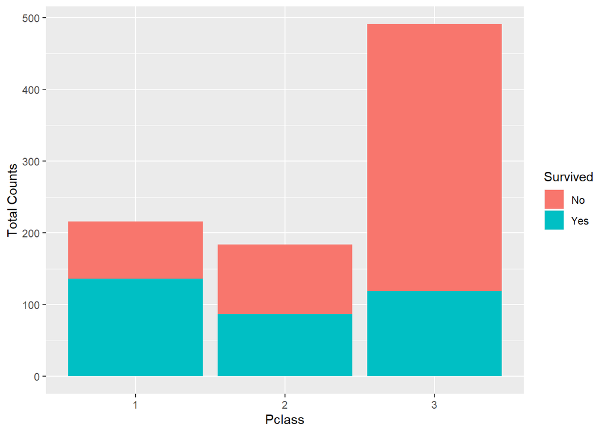

```r
ggplot(data = train, aes(x = Pclass, fill = Survived)) + geom_bar() + ylab("Total Counts")
```

Plotting the survival status of the passengers according to the gender

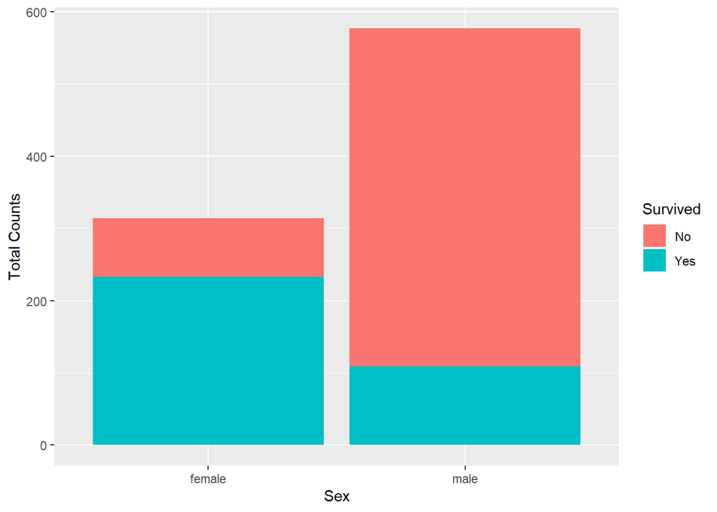

```r
ggplot(data = train, aes(x = Sex, fill = Survived)) + geom_bar() + ylab("Total Counts")
```

Plotting the survival status of the passangers according to the age

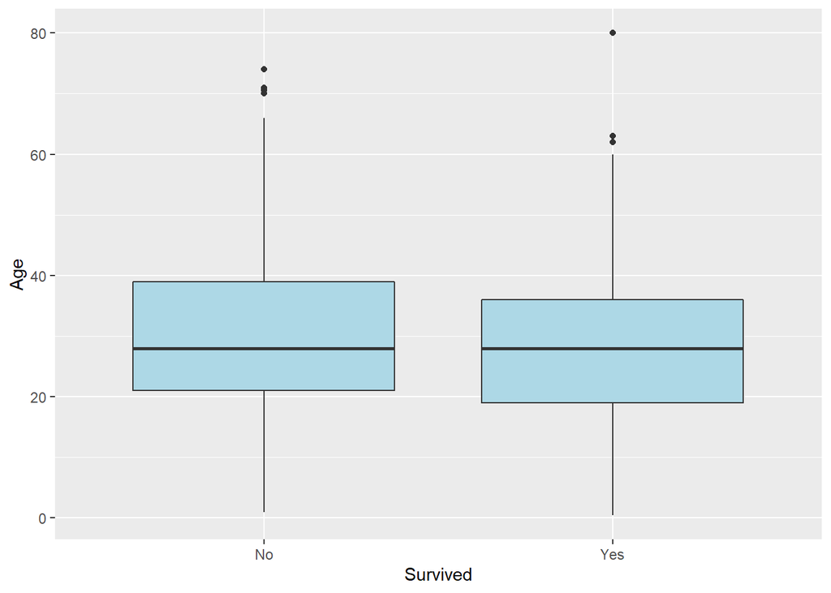

```r
ggplot(data = train, aes(y = Age, x = Survived)) + geom_boxplot(fill="lightblue")
```

# Extracting titles from the name variable.

```r
library(stringr)
ExtractTitle = function(name)
{
  Name = as.character(name)
  if (length(grep("Miss.", Name)) > 0)
    return("Miss.")
  else if (length(grep("Mrs.", Name)) > 0)
    return("Mrs.")
  else if (length(grep("Master.", Name)) > 0)
    return("Master.")
  else if (length(grep("Mr.", Name)) > 0)
    return("Mr.")
  else
    return("Other")
}
```

```r
Title = character()
for (i in 1:nrow(train))
  Title = c(Title, ExtractTitle(train$Name[i]))
table(Title)
```

```
## Title
## Master.   Miss.     Mr.    Mrs.   Other
##      40     182     518     127      24
```

transforming the variable “title” from string to factor-type.

```r
train$Title = as.factor(Title)
```

printing the top 5 rows of train dataset.

```r
head(train,5)
```

|  | PassengerId | Survived | Pclass | Name | Sex | Age | SibSp | Parch | Ticket | Fare | Cabin | Embarked | Title |
| --- | --- | --- | --- | --- | --- | --- | --- | --- | --- | --- | --- | --- | --- |
| 1 | 1 | No | 3 | Braund, Mr. Owen Harris | male | 22 | 1 | 0 | A/5 21171 | 7.2500 |  | S | Mr. |
| 2 | 2 | Yes | 1 | Cumings, Mrs. John Bradley (Florence Briggs Thayer) | female | 38 | 1 | 0 | PC 17599 | 71.2833 | C85 | C | Mrs. |
| 3 | 3 | Yes | 3 | Heikkinen, Miss. Laina | female | 26 | 0 | 0 | STON/O2. 3101282 | 7.9250 |  | S | Miss. |
| 4 | 4 | Yes | 1 | Futrelle, Mrs. Jacques Heath (Lily May Peel) | female | 35 | 1 | 0 | 113803 | 53.1000 | C123 | S | Mrs. |
| 5 | 5 | No | 3 | Allen, Mr. William Henry | male | 35 | 0 | 0 | 373450 | 8.0500 |  | S | Mr. |

Extracting boys from train dataset using the variable title.

```r
boys = train[which(train$Title=="Master."),]
```

printing the number of rows of the extracted dataset **boys**.

```r
nrow(boys)
```

```
## [1] 40
```

Summarizing the age of boys

```r
summary(boys$Age)
```

```
##    Min. 1st Qu.  Median    Mean 3rd Qu.    Max.    NA's
##   0.420   1.000   3.500   4.574   8.000  12.000       4
```

Creating age-group variable for the boys dataset

```r
boys$Agegroup = cut(boys$Age, breaks = c(0,4,7,12))
```

Printing a table view of the age-group.

```r
table(boys$Agegroup)
```

```
##
##  (0,4]  (4,7] (7,12]
##     23      3     10
```

Visualizing the Age of boys

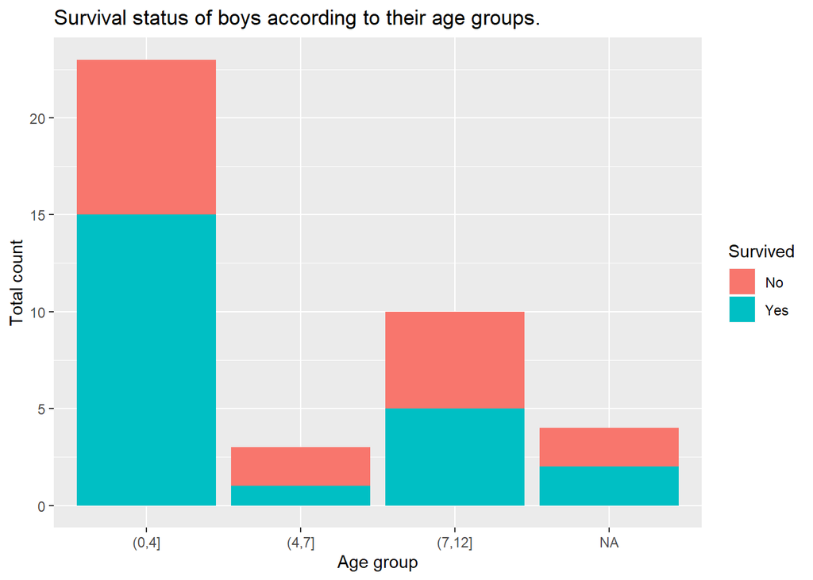

```r
ggplot(data = boys, aes(x = Agegroup, fill=Survived))+
geom_bar() +
ggtitle("Survival status of boys according to their age groups.")+
xlab("Age group")+
ylab("Total count")
```

Extracting **Miss.** from train dataset using the variable title.

```r
miss = train[which(train$Title=="Miss."),]
```

Creating Age-group variable for the girls dataset

```r
miss$Agegroup = cut(miss$Age, breaks = c(0,15,30,40, 80))
```

Printing a table-view of age-groups with their associated counts.

```r
table(miss$Agegroup)
```

```
##
##  (0,15] (15,30] (30,40] (40,80]
##      41      74      21      10
```

Plotting Survival status of misses according to their age groups

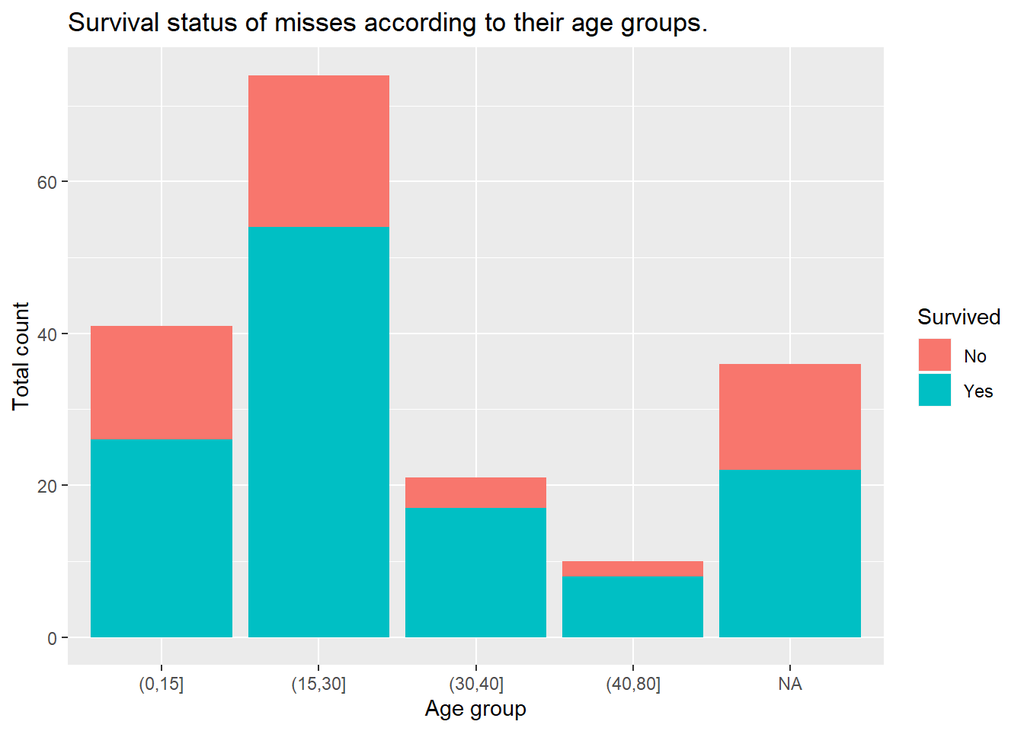

```r
ggplot(data = miss, aes(x = Agegroup, fill=Survived))+
geom_bar() +
ggtitle("Survival status of misses according to their age groups.")+
xlab("Age group")+
ylab("Total count")
```

```r
model = glm(Survived ~ Pclass + Sex + Pclass:Sex + Age + SibSp  , data = train, family = binomial(link = 'logit') )
```

```r
test = read.csv("D:\\Datasets\\Titanic\\test.csv")
test$Pclass =  as.factor(test$Pclass)
test$Name = as.character(test$Name)
summary(model)
```

```
##
## Call:
## glm(formula = Survived ~ Pclass + Sex + Pclass:Sex + Age + SibSp,
##     family = binomial(link = "logit"), data = train)
##
## Deviance Residuals:
##     Min       1Q   Median       3Q      Max
## -3.1880  -0.6578  -0.4273   0.3937   2.6123
##
## Coefficients:
##                  Estimate Std. Error z value Pr(>|z|)
## (Intercept)      5.550364   0.728868   7.615 2.64e-14 ***
## Pclass2         -1.272910   0.739246  -1.722  0.08509 .
## Pclass3         -4.298230   0.658852  -6.524 6.85e-11 ***
## Sexmale         -3.753632   0.634759  -5.913 3.35e-09 ***
## Age             -0.051738   0.009035  -5.726 1.03e-08 ***
## SibSp           -0.371481   0.119923  -3.098  0.00195 **
## Pclass2:Sexmale -0.694565   0.821034  -0.846  0.39757
## Pclass3:Sexmale  2.218994   0.691157   3.211  0.00132 **
## ---
## Signif. codes:  0 '***' 0.001 '**' 0.01 '*' 0.05 '.' 0.1 ' ' 1
##
## (Dispersion parameter for binomial family taken to be 1)
##
##     Null deviance: 964.52  on 713  degrees of freedom
## Residual deviance: 602.57  on 706  degrees of freedom
##   (177 observations deleted due to missingness)
## AIC: 618.57
##
## Number of Fisher Scoring iterations: 6
```

```r
anova(model, "Chisq")
```

|  | Df | Deviance | Resid. Df | Resid. Dev |
| --- | --- | --- | --- | --- |
| NULL | NA | NA | 713 | 964.5160 |
| Pclass | 2 | 94.70570 | 711 | 869.8103 |
| Sex | 1 | 197.37955 | 710 | 672.4307 |
| Age | 1 | 25.14758 | 709 | 647.2831 |
| SibSp | 1 | 10.71855 | 708 | 636.5646 |
| Pclass:Sex | 2 | 33.99719 | 706 | 602.5674 |

Predicting the probability of survival status for the first 10 passangers

```r
result = predict(model, test, type = 'response')
print(result[1:10])
```

```
##          1          2          3          4          5          6          7
## 0.11230126 0.17494060 0.03297522 0.15717281 0.43596084 0.26760098 0.42555977
##          8          9         10
## 0.13154140 0.57953369 0.10794053
```

Plotting the density of the prediction

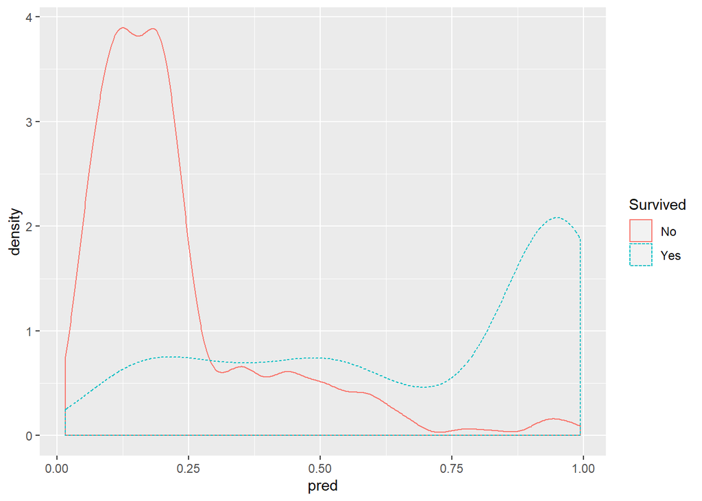

```r
train$pred <- predict(model, newdata=train, type="response")
test$pred <- predict(model, newdata=test, type="response")
ggplot(train, aes(x=pred, color=Survived, linetype=Survived)) +
geom_density()
```

## ————————–**End** ————————–